# **Lab 5**

```python
%matplotlib inline
import numpy as np
import matplotlib
import matplotlib.pyplot as plt
import scipy
import statistics
import math
from scipy import stats
import h5py
import pandas as pd
import pickle
```

### **Lab 5a**

Here, we are told to download the signal and background datasets which are labeled as "higgs" and "qcd" respectively. Each of these files contain 100k jets. Notice, we have 14 features which are printed from .keys(). Also, the Higgs and QCD data have the same features.

```python
# higgs data
higgs_file = open("higgs_100000_pt_250_500.pkl",'rb')
higgs_dict = pickle.load(higgs_file)
higgs_data = pd.DataFrame(higgs_dict)
print("Higgs Data:", higgs_data.keys())
```

```
Higgs Data: Index(['pt', 'eta', 'phi', 'mass', 'ee2', 'ee3', 'd2', 'angularity', 't1',
       't2', 't3', 't21', 't32', 'KtDeltaR'],
      dtype='object')
```

```python
# qcd data
qcd_file = open("qcd_100000_pt_250_500.pkl",'rb')
qcd_dict = pickle.load(qcd_file)
qcd_data = pd.DataFrame(qcd_dict)
print("QCD Data:", qcd_data.keys())
```

```
QCD Data: Index(['pt', 'eta', 'phi', 'mass', 'ee2', 'ee3', 'd2', 'angularity', 't1',
       't2', 't3', 't21', 't32', 'KtDeltaR'],
      dtype='object')
```

### **Lab 5b**

Here, we are supposed to explore the data. Specifically, we will investigate the following: 1) describe how the data was taken; 2) what the labels mean; and 3) how to interpret the first plots we have made. We are told the written report should be several pages long.

### **Exploring Data: Transverse Momentum**

The first feature is pT which is a label for transverse momentum which has units GeV. Specifically, the transverse momentum is the component of momentum which is perpendicular to the beamline. This can be calculated by taking the square root of the square of the x and y component of momentum on the xy-plane. So, transverse momentum on the xy-plane is given by the equation: $p_T = \sqrt{p_x^2+p_y^2}$.

According to the lab manual, a Higgs boson is produced at large transverse momentum. Below, we have a histogram and semi-log histogram of the Higgs data and the QCD background. The x-axis is the transverse momentum in GeV and the y-axis is the asssociated number of events (counts). We notice how there is a notable spike when the transverse momentum is a value of approximately 480 GeV. From this, we can infer a Higgs boson is produced when the transverse momentum is a value of approximately 480 GeV.

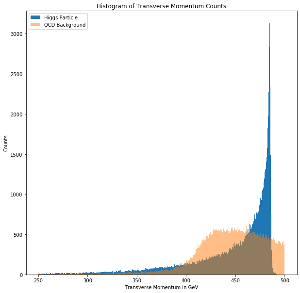

[figure not shown]

```python
# hist plot of pt counts
fig, ax = plt.subplots(1, 1, figsize=(10,10))
ax.hist(higgs_data.pt,500,label='Higgs Particle')
ax.hist(qcd_data.pt,500,alpha=.5,label='QCD Background')
ax.set_title("Histogram of Transverse Momentum Counts")
ax.legend(loc='upper left')
ax.set_xlabel("Transverse Momentum in GeV")
ax.set_ylabel("Counts")
plt.show()

# semi-log hist plot of pt counts
fig, ax = plt.subplots(1, 1, figsize=(10,10))
ax.hist(higgs_data.pt,500,label='Higgs Particle')
ax.hist(qcd_data.pt,500,alpha=.5,label='QCD Background')
ax.set_title("Semi-Log Histogram of Transverse Momentum Counts")
ax.legend(loc='upper left')
ax.set_xlabel("Transverse Momentum in GeV")
ax.set_ylabel("Counts in Log Scale")
ax.set_yscale('log')
plt.show()
```

### **Exploring Data: Pseudo-Rapidity**

The second feature is $\eta$ (eta) which is a label for pseudo-rapidity. Specifically, pseudo-rapidity is a commonly used spatial coordinate in experimental particle physics. It describes the angle of a particle relative to the beam axis. Pseudo-rapidity is given by the equation $\eta = -\ln[\tan(\frac{\theta}{2})]$, where $\theta$ represents the angle between the particle three-momentum $p$ and the positive direction of the beam axis. Another equation which describes pseudo-rapdiity as a function of three-momentum $p$ is: $\eta = arctanh(\frac{p_L}{|p|})$, where $p_L$ is the component of momentum parallel to the beam axis or longitudinal momentum. According to the lab manual, $\eta$ is a geometric quantity which is a function of polar angle $\theta$ that goes from $\inf$ to $-\inf$ as $\theta$ goes from 0 to $\pi$.

Here, we have a histogram which resembles a Gaussian distribution with a mean of zero. In particle physics, an angle of zero is generally along the beam axis. Thus, particles with large pseudo-rapidity values are lost which means we can reduce the background data by omitting data with a signal greater than $2\sigma$.

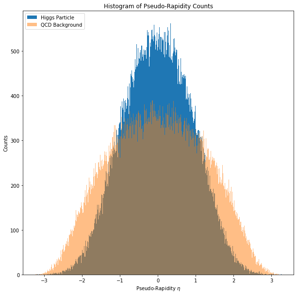

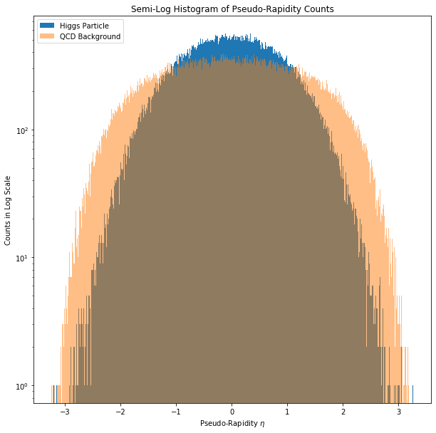

```python
# hist plot of eta counts
fig, ax = plt.subplots(1, 1, figsize=(10,10))
ax.hist(higgs_data.eta,500,label='Higgs Particle')
ax.hist(qcd_data.eta,500,alpha=.5,label='QCD Background')
ax.set_title("Histogram of Pseudo-Rapidity Counts")
ax.legend(loc='upper left')
ax.set_xlabel("Pseudo-Rapidity $\eta$")
ax.set_ylabel("Counts")
plt.show()

# semi-log hist plot of eta counts
fig, ax = plt.subplots(1, 1, figsize=(10,10))
ax.hist(higgs_data.eta,500,label='Higgs Particle')
ax.hist(qcd_data.eta,500,alpha=.5,label='QCD Background')
ax.set_title("Semi-Log Histogram of Pseudo-Rapidity Counts")
ax.legend(loc='upper left')
ax.set_xlabel("Pseudo-Rapidity $\eta$")
ax.set_ylabel("Counts in Log Scale")
ax.set_yscale('log')
plt.show()
```

### **Exploring Data: Azimuthal Angle**

The third feature is $\phi$ (phi) which is a label for the azimuthal angle. Specifically, the azimuthal angle is the angle between a plane perpendicular to the beam and a reference vector. The azimuthal angle is given by the equation: $\phi = \arccos(\frac{x}{r})$, where x is a plane perpendicular to the beam and r is a reference vector. According to the lab manual, the azimuthal angle goes around the beam.

Here, we cannot tell if there is any signficance of the azimuthal angle between the Higgs and QCD data. Specifically, there doesn't seem to be any distinguishable patterns or correlations in which we can comment on for the azimuthal angle between the Higgs and QCD data. At least, if we are talking about the counts of an azimuthal angle. Perhaps, there is some sort of valuable data in which we can observe if we were to weigh the azimuthal angle against other feature in the data set.

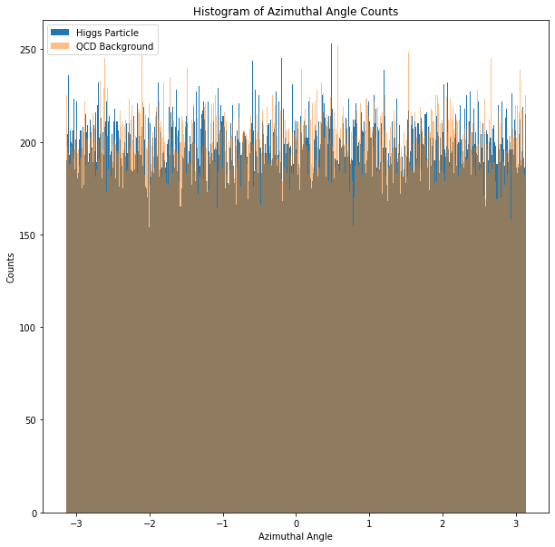

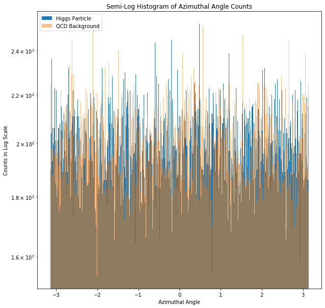

```python
# hist plot of phi counts
fig, ax = plt.subplots(1, 1, figsize=(10,10))
ax.hist(higgs_data.phi,500,label='Higgs Particle')
ax.hist(qcd_data.phi,500,alpha=.5,label='QCD Background')
ax.set_title("Histogram of Azimuthal Angle Counts")
ax.legend(loc='upper left')
ax.set_xlabel("Azimuthal Angle")
ax.set_ylabel("Counts")
plt.show()

# semi-log hist plot of phi counts
fig, ax = plt.subplots(1, 1, figsize=(10,10))
ax.hist(higgs_data.phi,500,label='Higgs Particle')
ax.hist(qcd_data.phi,500,alpha=.5,label='QCD Background')
ax.set_title("Semi-Log Histogram of Azimuthal Angle Counts")
ax.legend(loc='upper left')
ax.set_xlabel("Azimuthal Angle")
ax.set_ylabel("Counts in Log Scale")
ax.set_yscale('log')
plt.show()
```

### **Exploring Data: Mass**

The fourth feature is mass which has units GeV. Simply, this feature describes the mass of a particle. The mass is given by the equation $E^2 = p^2 + m^2$, where $E$ and $p$ are energy and momentum respectively.

From the histrogram plots, we notice a spike at approximately 125 GeV. According to Wikipedia, the Higgs boson has a mass of $125.18 ± 0.16 \frac{GeV}{c^2}$. This explains why we see a lot of counts around 125 GeV which is approximately the mass of the Higgs boson. Thus, our data is consistent with what we expect in reality.

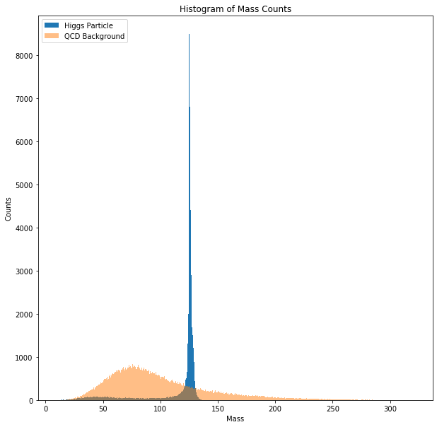

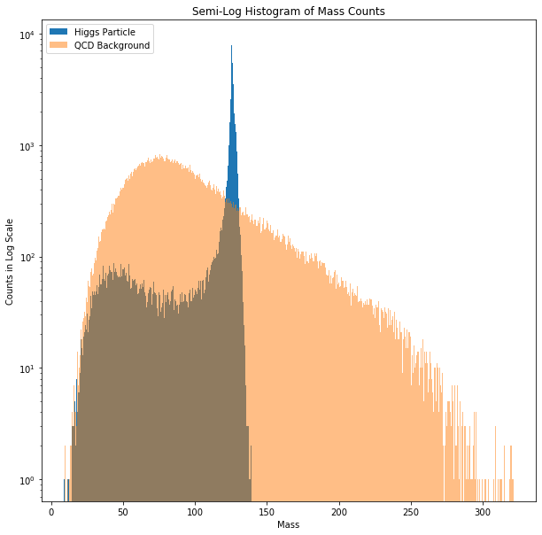

```python
# hist plot of mass counts
fig, ax = plt.subplots(1, 1, figsize=(10,10))
ax.hist(higgs_data.mass,500,label='Higgs Particle')
ax.hist(qcd_data.mass,500,alpha=.5,label='QCD Background')
ax.set_title("Histogram of Mass Counts")
ax.legend(loc='upper left')
ax.set_xlabel("Mass")
ax.set_ylabel("Counts")
plt.show()

# semi-log hist plot of mass counts
fig, ax = plt.subplots(1, 1, figsize=(10,10))
ax.hist(higgs_data.mass,500,label='Higgs Particle')
ax.hist(qcd_data.mass,500,alpha=.5,label='QCD Background')
ax.set_title("Semi-Log Histogram of Mass Counts")
ax.legend(loc='upper left')
ax.set_xlabel("Mass")
ax.set_ylabel("Counts in Log Scale")
ax.set_yscale('log')
plt.show()
```

### **Exploring Data: $E_{CF2}$**

The fifth feature is ee2 which is a label for the 2-Point $E_{CF}$ ratio where $E_{CF}$ is an energy correlation function. So, the 2-Point $E_{CF}$ can be written as $E_{CF2}$. Specifically, $E_{CF2}$ is the 2-Point energy correlation function for quark and gluon discrimination. The 2-Point $E_{CF}$ is given by equation (1) with $n=2$ in this document from Alex Schuy's repository called qsvm_jet_tagging: https://arxiv.org/pdf/1411.0665.pdf.

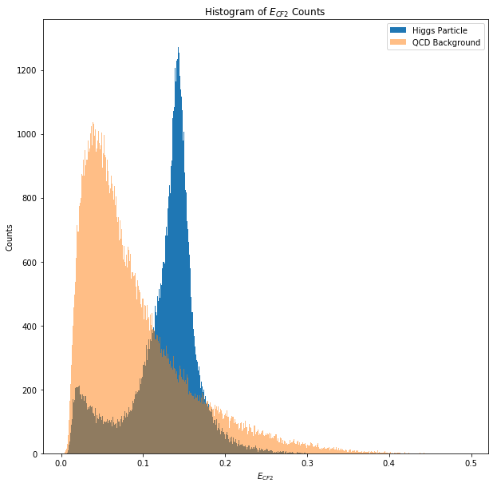

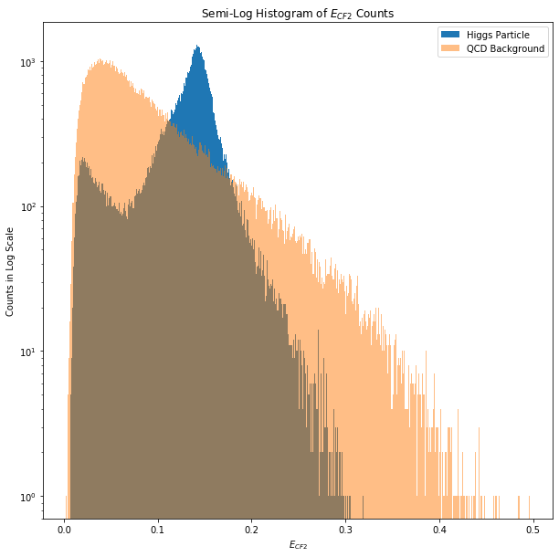

```python
# hist plot of ee2 counts
fig, ax = plt.subplots(1, 1, figsize=(10,10))
ax.hist(higgs_data.ee2,500,label='Higgs Particle')
ax.hist(qcd_data.ee2,500,alpha=.5,label='QCD Background')
ax.set_title("Histogram of $E_{CF2}$ Counts")
ax.legend(loc='upper right')
ax.set_xlabel("$E_{CF2}$")
ax.set_ylabel("Counts")
plt.show()

# semi-log hist plot of ee2 counts
fig, ax = plt.subplots(1, 1, figsize=(10,10))
ax.hist(higgs_data.ee2,500,label='Higgs Particle')
ax.hist(qcd_data.ee2,500,alpha=.5,label='QCD Background')
ax.set_title("Semi-Log Histogram of $E_{CF2}$ Counts")
ax.legend(loc='upper right')
ax.set_xlabel("$E_{CF2}$")
ax.set_ylabel("Counts in Log Scale")
ax.set_yscale('log')
plt.show()
```

### **Exploring Data: $E_{CF3}$**

The sixth feature is ee3 which is a label for the 3-Point $E_{CF}$ ratio where $E_{CF}$ is an energy correlation function. So, the 3-Point $E_{CF}$ can be written as $E_{CF3}$. Specifically, $E_{CF3}$ is the 3-Point energy correlation function for W, Z, and Higgs boson identification. The 3-Point $E_{CF}$ is given by equation (1) with $n=3$ in this document from Alex Schuy's repository called qsvm_jet_tagging: https://arxiv.org/pdf/1411.0665.pdf.

Here, we notice peaks at approximately 0 for the QCD background and a peak at a value greater than 0 but less than 0.01 for the Higgs data. We notice that much of the Higgs data is drowned in background noise thus it would be very difficult to detect given the significant background noise.

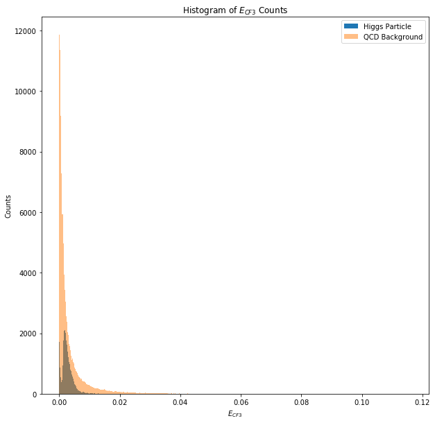

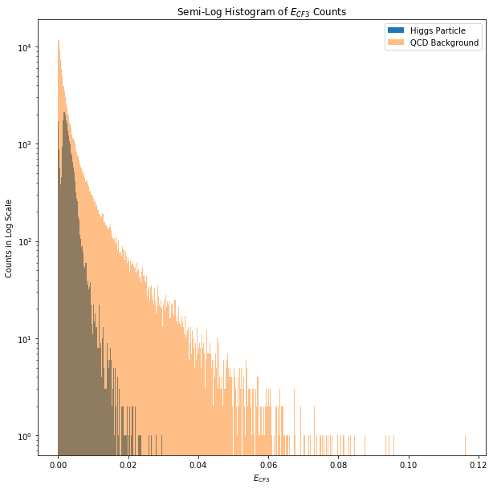

```python
# hist plot of ee3 counts
fig, ax = plt.subplots(1, 1, figsize=(10,10))
ax.hist(higgs_data.ee3,500,label='Higgs Particle')
ax.hist(qcd_data.ee3,500,alpha=.5,label='QCD Background')
ax.set_title("Histogram of $E_{CF3}$ Counts")
ax.legend(loc='upper right')
ax.set_xlabel("$E_{CF3}$")
ax.set_ylabel("Counts")
plt.show()

# semi-log hist plot of ee3 counts
fig, ax = plt.subplots(1, 1, figsize=(10,10))
ax.hist(higgs_data.ee3,500,label='Higgs Particle')
ax.hist(qcd_data.ee3,500,alpha=.5,label='QCD Background')
ax.set_title("Semi-Log Histogram of $E_{CF3}$ Counts")
ax.legend(loc='upper right')
ax.set_xlabel("$E_{CF3}$")
ax.set_ylabel("Counts in Log Scale")
ax.set_yscale('log')
plt.show()
```

### **Exploring Data: $D_2$**

The seventh feature is d2 which is a label for $D_2$. Specifically, $D_2$ is the two-prong jet discrimination which is a ratio of $E_{CF3}$ and $E_{CF2}$. So, $D_2$ is given by the equation: $D_2^{(\beta)} = \frac{E_{CF3}}{(E_{CF2})^3}$. This is from equation (3) in this document from Alex Schuy's repository called qsvm_jet_tagging: https://arxiv.org/pdf/1411.0665.pdf.

Here, we notice a peak at approximately 0 for the Higgs data and QCD background from the histograms below. It is difficult to tell if there is any significant data we can get from this considering $D_2$ describes a ratio of quark and gluon discrimation to W, Z, and Higgs boson identification.

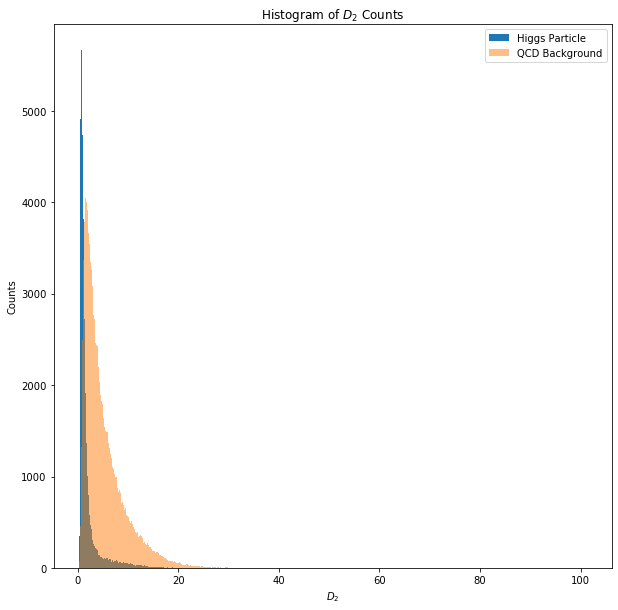

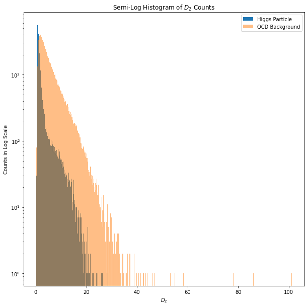

```python
# hist plot of d2 counts
fig, ax = plt.subplots(1, 1, figsize=(10,10))
ax.hist(higgs_data.d2,500,label='Higgs Particle')
ax.hist(qcd_data.d2,500,alpha=.5,label='QCD Background')
ax.set_title("Histogram of $D_2$ Counts")
ax.legend(loc='upper right')
ax.set_xlabel("$D_2$")
ax.set_ylabel("Counts")
plt.show()

# semi-log hist plot of d2 counts
fig, ax = plt.subplots(1, 1, figsize=(10,10))
ax.hist(higgs_data.d2,500,label='Higgs Particle')
ax.hist(qcd_data.d2,500,alpha=.5,label='QCD Background')
ax.set_title("Semi-Log Histogram of $D_2$ Counts")
ax.legend(loc='upper right')
ax.set_xlabel("$D_2$")
ax.set_ylabel("Counts in Log Scale")
ax.set_yscale('log')
plt.show()
```

### **Exploring Data: Angularity**

The eighth feature is angularity. Specifically, angularity describes a separator between QCD and heavy-object jets. From Alex Schruy's repository called qsvm_jet_tagging, the angularity is given by the equation: $\theta = \frac{1}{m_J} \sum_{i \in j} E_i \sin^{-2}(\theta)(1 - \cos^{3}(\theta))$, where $m_J$ is the mass of the jet.

Here, we notice a peak of approximately 0 in both the Higgs data and the QCD background in the histograms below. Specifically, the Higgs data has a peak of approximately 3000 counts while the QCD background has a peak of approximately 7000 counts. So we can infer that the angularity is much larger for the Higgs boson which is shown from the histogram below since the angularity at 0 is less for the Higgs data compared to the QCD background given our definition of angularity as a separator between QCD and heavy-object jets.

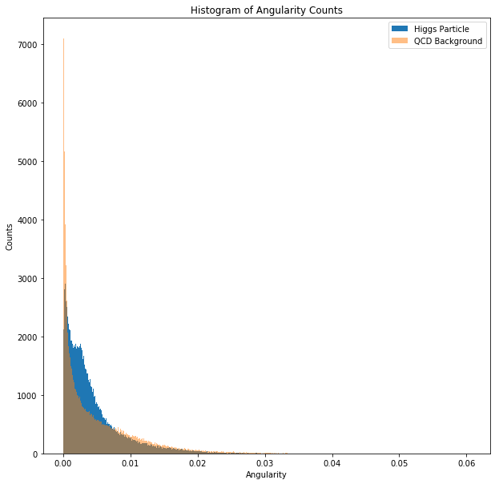

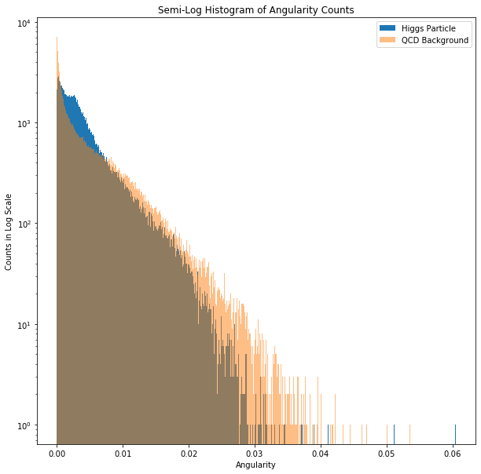

```python
# hist plot of angularity counts
fig, ax = plt.subplots(1, 1, figsize=(10,10))
ax.hist(higgs_data.angularity,500,label='Higgs Particle')
ax.hist(qcd_data.angularity,500,alpha=.5,label='QCD Background')
ax.set_title("Histogram of Angularity Counts")
ax.legend(loc='upper right')
ax.set_xlabel("Angularity")
ax.set_ylabel("Counts")
plt.show()

# semi-log hist plot of angularity counts
fig, ax = plt.subplots(1, 1, figsize=(10,10))
ax.hist(higgs_data.angularity,500,label='Higgs Particle')
ax.hist(qcd_data.angularity,500,alpha=.5,label='QCD Background')
ax.set_title("Semi-Log Histogram of Angularity Counts")
ax.legend(loc='upper right')
ax.set_xlabel("Angularity")
ax.set_ylabel("Counts in Log Scale")
ax.set_yscale('log')
plt.show()
```

### **Exploring Data: $\tau_1$**

The ninth feature is t1 which is a label for $\tau_1$. Specifically $\tau_1$ is the 1-subjettiness. $\tau_1$ is given by the equation: $\tau_n = \frac{1}{d_0} \sum_{k=1}(p_{T,k}\min{\Delta R_{1,k}, \Delta R_{2,k}, ..., \Delta R_{N,k}})$ with $n=1$. Here, $d_0$ is the normalization factor given by the equation $d_0 = \sum_k p_{T,k}R_0$, where $R_0$ is the characteristic jet radius used in the original jet clustering algorithm. So, we can see that $\tau_1$ describes a jet composed of 1 subjet. We found the equation given by equation (2.2) in this document: https://arxiv.org/pdf/1011.2268.pdf.

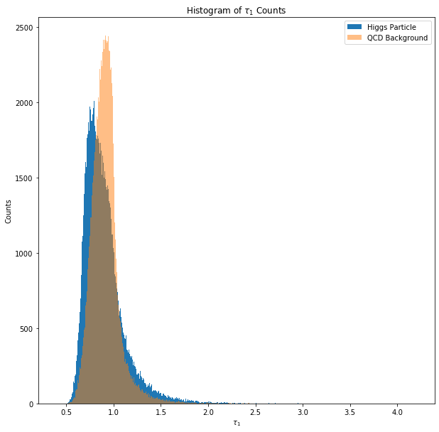

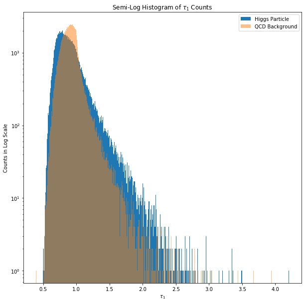

```python
# hist plot of t1 counts
fig, ax = plt.subplots(1, 1, figsize=(10,10))
ax.hist(higgs_data.t1,500,label='Higgs Particle')
ax.hist(qcd_data.t1,500,alpha=.5,label='QCD Background')
ax.set_title("Histogram of $τ_1$ Counts")
ax.legend(loc='upper right')
ax.set_xlabel("$τ_1$")
ax.set_ylabel("Counts")
plt.show()

# semi-log hist plot of t1 counts
fig, ax = plt.subplots(1, 1, figsize=(10,10))
ax.hist(higgs_data.t1,500,label='Higgs Particle')
ax.hist(qcd_data.t1,500,alpha=.5,label='QCD Background')
ax.set_title("Semi-Log Histogram of $τ_1$ Counts")
ax.legend(loc='upper right')
ax.set_xlabel("$τ_1$")
ax.set_ylabel("Counts in Log Scale")
ax.set_yscale('log')
plt.show()
```

### **Exploring Data: $\tau_2$**

The tenth feature is t2 which is a label for $\tau_2$. Specifically $\tau_2$ is the 2-subjettiness. $\tau_2$ is given by the equation: $\tau_n = \frac{1}{d_0} \sum_{k=1}(p_{T,k}\min{\Delta R_{1,k}, \Delta R_{2,k}, ..., \Delta R_{N,k}})$ with $n=2$. Here, $d_0$ is the normalization factor given by the equation $d_0 = \sum_k p_{T,k}R_0$, where $R_0$ is the characteristic jet radius used in the original jet clustering algorithm. So, we can see that $\tau_2$ describes a jet composed of 2 subjets. We found the equation given by equation (2.2) in this document: https://arxiv.org/pdf/1011.2268.pdf.

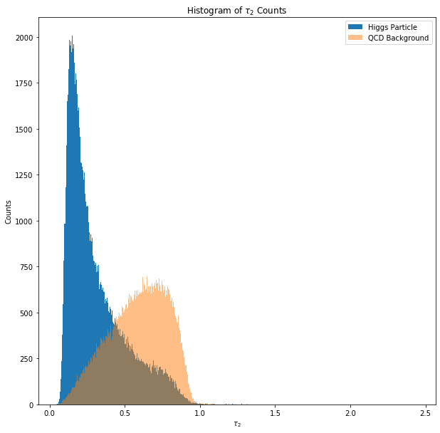

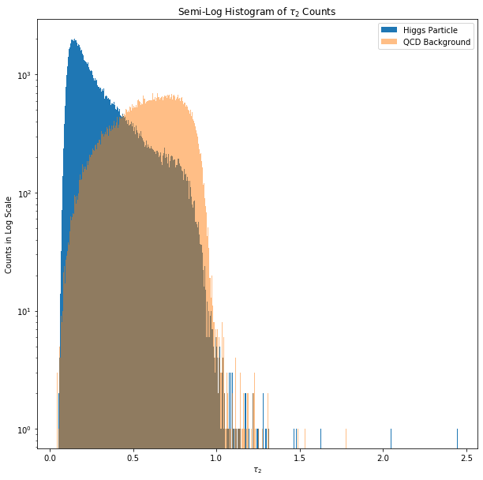

```python
# hist plot of t2 counts
fig, ax = plt.subplots(1, 1, figsize=(10,10))
ax.hist(higgs_data.t2,500,label='Higgs Particle')
ax.hist(qcd_data.t2,500,alpha=.5,label='QCD Background')
ax.set_title("Histogram of $τ_2$ Counts")
ax.legend(loc='upper right')
ax.set_xlabel("$τ_2$")
ax.set_ylabel("Counts")
plt.show()

# semi-log hist plot of t2 counts
fig, ax = plt.subplots(1, 1, figsize=(10,10))
ax.hist(higgs_data.t2,500,label='Higgs Particle')
ax.hist(qcd_data.t2,500,alpha=.5,label='QCD Background')
ax.set_title("Semi-Log Histogram of $τ_2$ Counts")
ax.legend(loc='upper right')
ax.set_xlabel("$τ_2$")
ax.set_ylabel("Counts in Log Scale")
ax.set_yscale('log')
plt.show()
```

### **Exploring Data: $\tau_3$**

The eleventh feature is t3 which is a label for $\tau_3$. Specifically $\tau_3$ is the 3-subjettiness. $\tau_3$ is given by the equation: $\tau_3 = \frac{1}{d_0} \sum_{k=1}(p_{T,k}\min{\Delta R_{1,k}, \Delta R_{2,k}, ..., \Delta R_{N,k}})$ with $n=3$. Here, $d_0$ is the normalization factor given by the equation $d_0 = \sum_k p_{T,k}R_0$, where $R_0$ is the characteristic jet radius used in the original jet clustering algorithm. So, we can see that $\tau_3$ describes a jet composed of 3 subjets. We found the equation given by equation (2.2) in this document: https://arxiv.org/pdf/1011.2268.pdf.

Here, we notice that there is a peak at approximately 0.1 in the Higgs data and a peak at approximately 0.5 in the QCD background. However, we have much more counts at the peak of the Higgs data compared to the peak of the QCD background. Specifically, the Higgs data has a peak of approximately 1200 counts while the QCD background has a peak of approximately 450 counts. Also, the Higgs data is not drowned by the background.

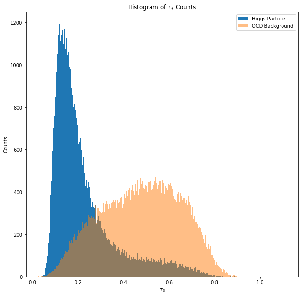

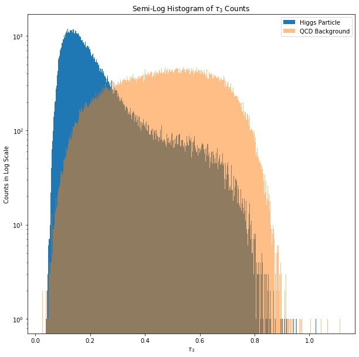

```python
# hist plot of t3 counts
fig, ax = plt.subplots(1, 1, figsize=(10,10))
ax.hist(higgs_data.t3,500,label='Higgs Particle')
ax.hist(qcd_data.t3,500,alpha=.5,label='QCD Background')
ax.set_title("Histogram of $τ_3$ Counts")
ax.legend(loc='upper right')
ax.set_xlabel("$τ_3$")
ax.set_ylabel("Counts")
plt.show()

# semi-log hist plot of t3 counts
fig, ax = plt.subplots(1, 1, figsize=(10,10))
ax.hist(higgs_data.t3,500,label='Higgs Particle')
ax.hist(qcd_data.t3,500,alpha=.5,label='QCD Background')
ax.set_title("Semi-Log Histogram of $τ_3$ Counts")
ax.legend(loc='upper right')
ax.set_xlabel("$τ_3$")
ax.set_ylabel("Counts in Log Scale")
ax.set_yscale('log')
plt.show()
```

### **Exploring Data: $\tau_{21}$**

The twelth feature is t21 which is a label for $\tau_{21}$. Specifically, $\tau_{21}$ describes the ratio of $\tau_2$ and $\tau_1$. So, $\tau_{21}$ is given by the equation: $\tau_{ji} = \frac{\tau_j}{\tau_i}$, where $j=2$ and $i=1$. Here, j must be larger than i such that $j > i$.

Here, we have two histogram plots of $\tau_{21}$ of the Higgs data and the QCD background. We notice that $\tau_{21}$ is a ratio which shows a peak at approximately 0.2 in the Higgs data and a peak at approximately 0.75 in the QCD background. Since we know $\tau_{21}$ is a ratio of $\tau_2$ and $\tau_1$, we know that $\tau_1$ must be much larger than $\tau_2$ in the Higgs data but $\tau_2$ and $\tau_1$ are somewhat similar in the QCD background. Also, the peaks of the Higgs data is not drowned in background noise.

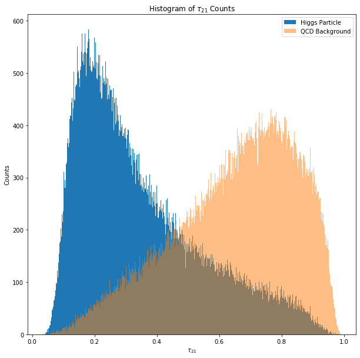

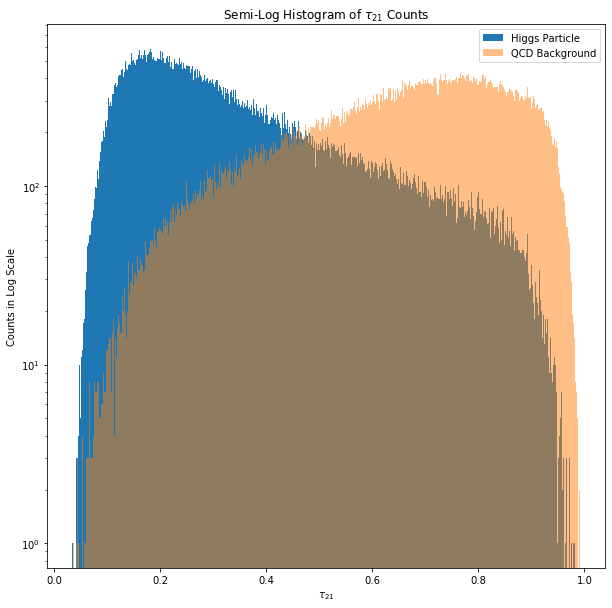

```python
# hist plot of t21 counts
fig, ax = plt.subplots(1, 1, figsize=(10,10))
ax.hist(higgs_data.t21,500,label='Higgs Particle')
ax.hist(qcd_data.t21,500,alpha=.5,label='QCD Background')
ax.set_title("Histogram of $τ_{21}$ Counts")
ax.legend(loc='upper right')
ax.set_xlabel("$τ_{21}$")
ax.set_ylabel("Counts")
plt.show()

# semi-log hist plot of t21 counts
fig, ax = plt.subplots(1, 1, figsize=(10,10))
ax.hist(higgs_data.t21,500,label='Higgs Particle')
ax.hist(qcd_data.t21,500,alpha=.5,label='QCD Background')
ax.set_title("Semi-Log Histogram of $τ_{21}$ Counts")
ax.legend(loc='upper right')
ax.set_xlabel("$τ_{21}$")
ax.set_ylabel("Counts in Log Scale")
ax.set_yscale('log')
plt.show()
```

### **Exploring Data: $\tau_{32}$**

The thirteenth feature is t32 which is a label for $\tau_{32}$. Specifically, $\tau_{32}$ describes the ratio of $\tau_3$ and $\tau_2$. So, $\tau_{32}$ is given by the equation: $\tau_{ji} = \frac{\tau_j}{\tau_i}$, where $j=3$ and $i=2$. Here, j must be larger than i such that $j > i$.

Here, we have two histogram plots of $\tau_{32}$ of the Higgs data and the QCD background. We notice that there is a lot of overlap between the counts of this feature which means there is a lot of background noise. However, we have larger values of $\tau_{32}$ in the Higgs data compared to the QCD background in the range which is approximately from 0.2 to 0.7. However, there is just too much background noise that we are unsure if this has any significance. We should note that the histograms of $\tau_{32}$ is very different than $\tau_{21}$ which may be a significant insight. Also, we notice a gradual increase in the histogram where the data peaks at approximately 0.8.

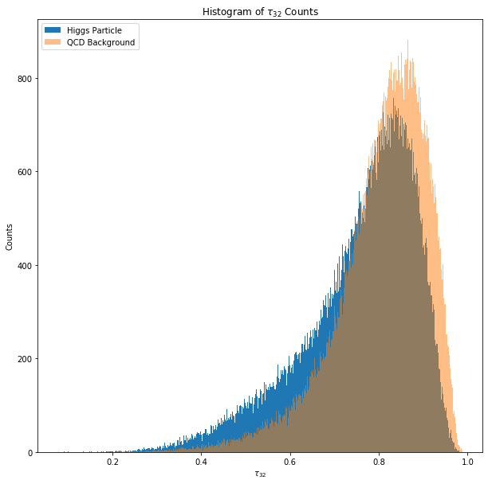

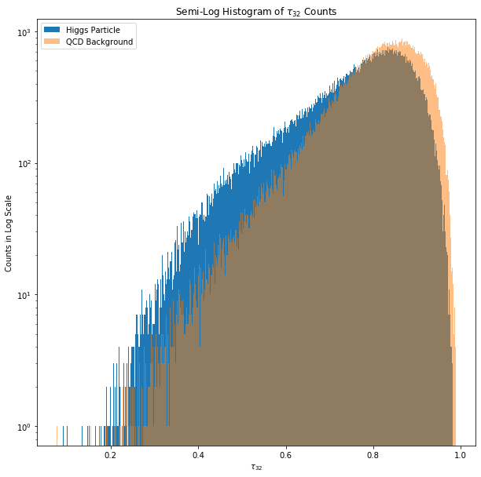

```python
# hist plot of t32 counts
fig, ax = plt.subplots(1, 1, figsize=(10,10))
ax.hist(higgs_data.t32,500,label='Higgs Particle')
ax.hist(qcd_data.t32,500,alpha=.5,label='QCD Background')
ax.set_title("Histogram of $τ_{32}$ Counts")
ax.legend(loc='upper left')
ax.set_xlabel("$τ_{32}$")
ax.set_ylabel("Counts")
plt.show()

# semi-log hist plot of t32 counts
fig, ax = plt.subplots(1, 1, figsize=(10,10))
ax.hist(higgs_data.t32,500,label='Higgs Particle')
ax.hist(qcd_data.t32,500,alpha=.5,label='QCD Background')
ax.set_title("Semi-Log Histogram of $τ_{32}$ Counts")
ax.legend(loc='upper left')
ax.set_xlabel("$τ_{32}$")
ax.set_ylabel("Counts in Log Scale")
ax.set_yscale('log')
plt.show()
```

### **Exploring Data: $k_t \Delta R$**

The fourteenth feature is ktDeltaR which is a label for $k_t \Delta R$. Specifically, $k_t \Delta R$ is the jet substructure moment. $k_t \Delta R$ is given by the equation: $\Delta R = \sqrt{\Delta \eta^2 + \Delta \phi^2}$. According the the lab manual, R is the cone size of a jet. So, $k_t \Delta R$ can be described as a cluster sequence where $\Delta R$ of two subjets within a large-R jet.

Below, we have histograms of the counts of $k_t \Delta R$. We notice there are spikes at approximately 0 and 0.5 for the Higgs data and spikes at approximately 0 for the QCD background. So, there is a spike at approximately 0 for the Higgs data but it would be very difficult to detect considering there is very large background noise. However, it would be easier to detect the spike at approximately 0.5 since there is less background noise. We assume these spikes are signficant because they tell us that the difference of the radius of the subjets have to be a certain value. At least, this is what we can get from the data since there are many counts at approximately 0 and 0.5, but we don't know this for certain.

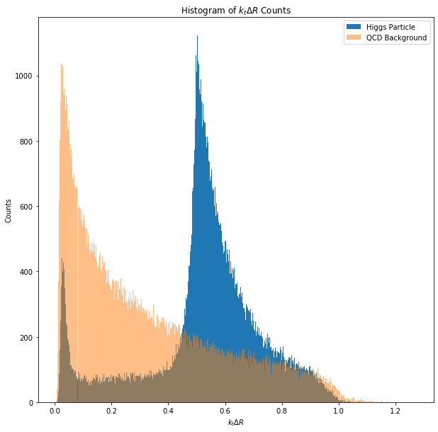

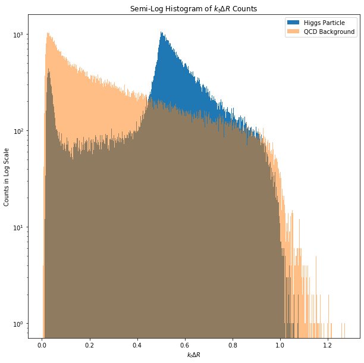

```python
# hist plot of KtDeltaR counts
fig, ax = plt.subplots(1, 1, figsize=(10,10))
ax.hist(higgs_data.KtDeltaR,500,label='Higgs Particle')
ax.hist(qcd_data.KtDeltaR,500,alpha=.5,label='QCD Background')
ax.set_title("Histogram of $k_t \Delta R$ Counts")
ax.legend(loc='upper right')
ax.set_xlabel("$k_t \Delta R$")
ax.set_ylabel("Counts")
plt.show()

# semi-log hist plot of KtDeltaR counts
fig, ax = plt.subplots(1, 1, figsize=(10,10))
ax.hist(higgs_data.KtDeltaR,500,label='Higgs Particle')
ax.hist(qcd_data.KtDeltaR,500,alpha=.5,label='QCD Background')
ax.set_title("Semi-Log Histogram of $k_t \Delta R$ Counts")
ax.legend(loc='upper right')
ax.set_xlabel("$k_t \Delta R$")
ax.set_ylabel("Counts in Log Scale")
ax.set_yscale('log')
plt.show()
```